# Equality of Opportunity Seminar Paper

Data Science and Machine Learning 2187 & 2087

Leonard Fidlin, Daniel Jost, Anne Valder

14 1 2021

# **Introduction**

```r
library(rpart)
library(rpart.plot)
library(precrec)
library(caret)
library(party)
library(partykit)
library(tidyverse)
library(vcd)
library(RColorBrewer)
library(knitr)
library(glmnet)
library(haven)
library(fst)
library(ranger)
library(tuneRanger)
library(xgboost)
library(readr)
```

# **Data Wrangling**

```r
data_path ="."
getwd()
```

```
## [1] "/Users/annevalder/Desktop/UNI /WU WIEN/WS20_21/2187-2087_WS2020_Data_Science-Machine_learning/01_Data Science Seminar Paper"
```

```r
hhi2019 <- read_sav(file.path(data_path,"wetransfer-a0b059", "hhi2019en_1.0.sav"))
wrk2019 <- read_sav(file.path(data_path,"wetransfer-a0b059", "wrk2019en_1.2.sav"))
inc2019 <- read_sav(file.path(data_path,"wetransfer-a0b059", "inc2019en_1.0.sav"))

write_csv(x = hhi2019, path = "hhi2019.csv" )
hhi2019csv <- read.csv(file.path(data_path, "hhi2019.csv"))

write_csv(x = inc2019, path = "inc2019.csv" )
inc2019csv <- read.csv(file.path(data_path, "inc2019.csv"))

write_csv(x = wrk2019, path = "wrk2019.csv" )
wrk2019csv <- read.csv(file.path(data_path, "wrk2019.csv"))

sub_wrk2019csv <- wrk2019csv %>% select(c(nohhold,burgst, branche))
sub_inc2019csv <- inc2019csv %>% select(c(nohhold, ij161, in49a))

join <- hhi2019csv %>% left_join(sub_wrk2019csv, by ="nohhold")
netherlands_survey_data <- join %>%  left_join(sub_inc2019csv, by = "nohhold")

summary(netherlands_survey_data) %>% head()
```

```
##     nohhold          nomem           gebjaar        geslacht
##  Min.   :    6   Min.   : 1.000   Min.   :1925   Min.   :1.000
##  1st Qu.:24512   1st Qu.: 1.000   1st Qu.:1956   1st Qu.:1.000
##  Median :45267   Median : 2.000   Median :1972   Median :2.000
##  Mean   :46030   Mean   : 2.192   Mean   :1975   Mean   :1.504
##  3rd Qu.:67057   3rd Qu.: 3.000   3rd Qu.:1994   3rd Qu.:2.000
##  Max.   :89986   Max.   :10.000   Max.   :2019   Max.   :2.000
##     positie          oplzon          oplmet         bezighei
##  Min.   :1.000   Min.   :1.000   Min.   :1.000   Min.   : 0.000
##  1st Qu.:1.000   1st Qu.:3.000   1st Qu.:3.000   1st Qu.: 1.000
##  Median :2.000   Median :5.000   Median :5.000   Median : 6.000
##  Mean   :2.614   Mean   :4.882   Mean   :4.886   Mean   : 5.035
##  3rd Qu.:5.000   3rd Qu.:6.000   3rd Qu.:6.000   3rd Qu.: 8.000
##  Max.   :7.000   Max.   :9.000   Max.   :9.000   Max.   :13.000
##     aantalhh        aantalki          sted           regio
##  Min.   :1.000   Min.   :0.000   Min.   :1.000   Min.   :1.000
##  1st Qu.:2.000   1st Qu.:0.000   1st Qu.:2.000   1st Qu.:2.000
##  Median :3.000   Median :1.000   Median :3.000   Median :3.000
##  Mean   :3.237   Mean   :1.245   Mean   :3.192   Mean   :3.219
##  3rd Qu.:4.000   3rd Qu.:2.000   3rd Qu.:4.000   3rd Qu.:4.000
##  Max.   :8.000   Max.   :6.000   Max.   :5.000   Max.   :5.000
##       prov          woonvorm        account          kostwin
##  Min.   :20.00   Min.   :1.000   Min.   :0.0000   Min.   :0.0000
##  1st Qu.:25.00   1st Qu.:2.000   1st Qu.:0.0000   1st Qu.:0.0000
##  Median :27.00   Median :3.000   Median :0.0000   Median :0.0000
##  Mean   :26.51   Mean   :2.681   Mean   :0.3909   Mean   :0.3908
##  3rd Qu.:29.00   3rd Qu.:3.000   3rd Qu.:1.0000   3rd Qu.:1.0000
##  Max.   :31.00   Max.   :5.000   Max.   :1.0000   Max.   :1.0000
##     partner           woning          burgst         branche
##  Min.   :0.0000   Min.   :1.000   Min.   :1.000   Min.   : 1.000
##  1st Qu.:1.0000   1st Qu.:1.000   1st Qu.:1.000   1st Qu.: 6.000
##  Median :1.0000   Median :1.000   Median :1.000   Median :11.000
##  Mean   :0.8744   Mean   :1.239   Mean   :2.459   Mean   : 9.793
##  3rd Qu.:1.0000   3rd Qu.:1.000   3rd Qu.:4.000   3rd Qu.:13.000
##  Max.   :1.0000   Max.   :4.000   Max.   :6.000   Max.   :15.000
##      ij161            in49a
##  Min.   :     0   Min.   :     0
##  1st Qu.: 12500   1st Qu.: 24000
##  Median : 33000   Median : 38000
##  Mean   : 35643   Mean   : 40851
##  3rd Qu.: 51000   3rd Qu.: 52000
##  Max.   :211000   Max.   :510000
```

```r
sum(is.na(netherlands_survey_data$in49a))
```

```
## [1] 7284
```

```r
netherlands_survey_clean <- netherlands_survey_data %>% as_data_frame()  %>% drop_na(in49a)


netherlands_survey_clean <- netherlands_survey_clean %>% mutate(
                    #drop_na(in49a),
                    income_K = (in49a/1000),
                    age = as.numeric(2019 - gebjaar)) %>%
                    rename(
                          "household_ID" = nohhold,
                          "birthyear" = gebjaar,
                          "gender" = geslacht,
                          "educ" = oplmet,
                          "occupation" = bezighei,
                          "num_hhold_memb" = aantalhh,
                          "num_hhold_children" = aantalki,
                          "urbanization" =  sted,
                          "region"= regio,
                          "hhold_type" = woonvorm,
                          "tenancy" = woning,
                          "industry" = branche)
```

# **Research Question**

The selection of circumstances is a key aspect for an empirical analysis of inequality of opportunity, because estimates have been shown to be sensitive to the number of types considered (Brunori and Neidhoefer 2020).

# **Data**

Brunori and Neidhoefer (2020) choose the circumstances based on the data quality in their survey data. Opting for fewer missing entries in each category than other characteristics. In their German focused paper they use: sex, migration background, resident in either East or West Germany (not important for our Dutch sample), Father’s and Mother’s education and training, Father’s and Mother’s occupation measured by the ISCO code, number of siblings, and an indicator of dissability. Their sample is further restricted to ages 30-60. In their “original” EU-SILC data paper the use the following circumstances which we could find in the Dutch data:

General Household Information: Respondents sex (male, female) (GESLACHT), number of household members (AANTALHH), number of children in the household (AANTALKI), Highest level of education completed (OPLMET), primary occupation of the respondent (BEZIGHEI), type of accommodation (WONING).

Questionaire Household and Work: Marital Status (BURGST), Father/Mother main occupation/job (BRANCHE),

Total Gross Income Category (IJ161BR thru IJ16BR3), Total Net income of household (INKHH) Inheritance? If yes then: Inheritance of 100,000 or 500,000 should make sense: (HER2), (HER3)

Questionaire on Accommodation and mortgages: tenancy status (WO1)

What we dont have is migration status, number of working adults in households, managerial position of father/mother. Further we do not have indicators on the educational endowment of the parents of the questioned individuals.

# **Method**: Conditional Inference Trees

- `ctree` from party package in R
- recursive partitioning just like `rpart`
- `rpart`: maximizing an information measure
- `ctree`: significance test procedure

### Advantages

**Advantages of Trees:** straightforward to interpret

**Advantages of Trees over linear regression models:** very large set of observations can be used & model speciﬁcation is no longer exogenously given

**Advantages of Conditional Inference Trees over Regression and Classification Trees (CART):** the algorithm automatically provides a test for the null hypothesis of equality of opportunity & prevents overfitting while CART “cannot distinguish between a significant and an insignificant improvement in the information measure” (Mingers 1987, as cited in Torsten Hothorn (n.d.), 2) & consider the distributional properties of the measures.

### Procedure

The algorithm follows a stepwise procedure (Brunori and Neidhoefer 2020, 7–8):

1. **Choose confidence level**
2. **Choose feature:** test all the null hypotheses of independence between the individual outcome and each of all the observable circumstances
   1. no hypothesis can be rejected: stop
   2. one or more circumstance is siginificant: select the circumstance with the smallest p-value and proceed
3. **Choose split:** for every possible way the selected circumstance can divide the sample into two subgroups, test the hypothesis of same mean outcome in the two resulting subgroups. Choose the splitting point with the smallest p-value
4. **Repeat :)**

# **Regression tree**

```r
set.seed(123)

netherlands_survey_clean <- netherlands_survey_clean %>%
  mutate(train_index = sample(c("train", "test"), nrow(netherlands_survey_clean), replace=TRUE, prob=c(0.85, 0.15)))

train <- netherlands_survey_clean %>% filter(train_index=="train")
test <- netherlands_survey_clean %>% filter(train_index=="test")

formula <- income_K ~ gender + educ + occupation + num_hhold_memb + num_hhold_children + urbanization + region + hhold_type + tenancy + industry

Rtree <- rpart(formula, data = train, cp=.01)
Rtree
```

```
## n= 3692
##
## node), split, n, deviance, yval
##       * denotes terminal node
##
##  1) root 3692 4047385.000  40.90544
##    2) tenancy>=1.5 675  482249.300  26.05070 *
##    3) tenancy< 1.5 3017 3382864.000  44.22893
##      6) num_hhold_children< 0.5 1583 1625743.000  37.88148
##       12) educ< 3.5 530  358044.100  29.23388 *
##       13) educ>=3.5 1053 1208117.000  42.23402 *
##      7) num_hhold_children>=0.5 1434 1622935.000  51.23591
##       14) num_hhold_memb>=7.5 62    9299.292  18.06935 *
##       15) num_hhold_memb< 7.5 1372 1542353.000  52.73469
##         30) industry>=2 1325 1194862.000  51.78649 *
##         31) industry< 2 47  312716.200  79.46562
##           62) num_hhold_memb< 4.5 26   18530.830  46.91862 *
##           63) num_hhold_memb>=4.5 21  232543.800 119.76190 *
```

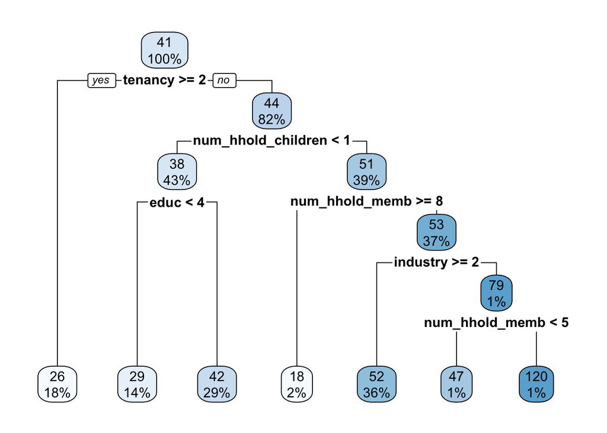

```r
rpart.plot(Rtree, nn=FALSE, type=2)
```

```r
control <- trainControl(method = "repeatedcv", number = 10, repeats = 10, savePredictions = T, classProbs = T, summaryFunction = multiClassSummary)

tuning_grid <- expand.grid(cp = seq(0, 0.02, by= 0.005))
tuning_grid

tree_caret <- train(data = netherlands_survey_clean, formula , method = "rpart", trControl = control, tuneGrid = tuning_grid, metric = "Accuracy", na.action = na.pass)
tree_caret
```

[output not shown]

# **Conditional inference tree**

```r
Ctree <- ctree(formula, data = train)
Ctree
```

```
##
## Model formula:
## income_K ~ gender + educ + occupation + num_hhold_memb + num_hhold_children +
##     urbanization + region + hhold_type + tenancy + industry
##
## Fitted party:
## [1] root
## |   [2] tenancy <= 1
## |   |   [3] num_hhold_children <= 0
## |   |   |   [4] educ <= 3: 29.234 (n = 530, err = 358044.1)
## |   |   |   [5] educ > 3
## |   |   |   |   [6] educ <= 6: 39.989 (n = 858, err = 836587.8)
## |   |   |   |   [7] educ > 6: 52.110 (n = 195, err = 348185.8)
## |   |   [8] num_hhold_children > 0
## |   |   |   [9] urbanization <= 3
## |   |   |   |   [10] industry <= 1
## |   |   |   |   |   [11] num_hhold_children <= 2: 37.879 (n = 14, err = 8419.3)
## |   |   |   |   |   [12] num_hhold_children > 2: 216.000 (n = 5, err = 23120.0)
## |   |   |   |   [13] industry > 1: 52.706 (n = 735, err = 565394.7)
## |   |   |   [14] urbanization > 3
## |   |   |   |   [15] num_hhold_memb <= 6: 51.785 (n = 618, err = 808493.1)
## |   |   |   |   [16] num_hhold_memb > 6: 18.069 (n = 62, err = 9299.3)
## |   [17] tenancy > 1: 26.051 (n = 675, err = 482249.3)
##
## Number of inner nodes:    8
## Number of terminal nodes: 9
```

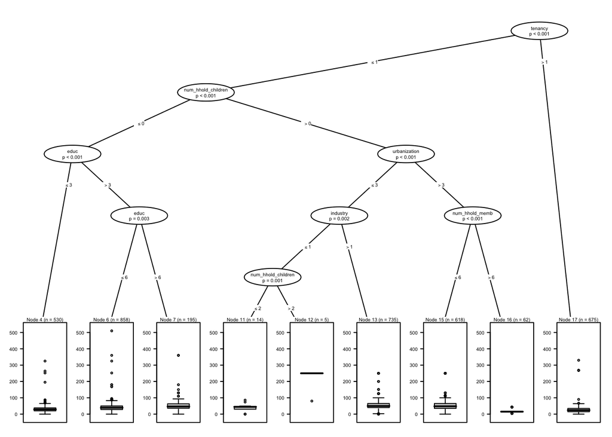

```r
plot(Ctree, gp = gpar(fontsize = 4),
  inner_panel=node_inner,
  ip_args=list(id = FALSE))
```

```r
test$prediction_Ctree <- predict(Ctree, newdata = test, type = c())

test$prediction_Ctree <- as.factor(test$prediction_Ctree)
test$income_K <- as.factor(test$income_K)

class(test$income_K)
class(test$prediction_Ctree)

confusionR <- confusionMatrix(test$income_K, test$prediction_Ctree, mode="sens_spec")
confusionR
```

[output not shown]

# **References**

Brunori, Paolo, and Guido Neidhoefer. 2020. “The Evolution of Inequality of Opportunity in Germany: A Machine Learning Approach.” SERIES 01-2020. Dipartimento di Economia e Finanza - Università degli Studi di Bari "Aldo Moro". http://www.seriesworkingpapers.it/RePEc/bai/series/SERIES_WP_01-2020.pdf.

Torsten Hothorn, Achim Zeileis, Kurt Hornik. n.d. “Ctree: Conditional Inference Trees: R Vignette.” https://cran.r-project.org/web/packages/partykit/vignettes/ctree.pdf.